# HW3-Coding

## Q4 Kernel Power on SVM and Regularized Logistic Regression

```python
import pandas as pd
import numpy as np
import matplotlib.pyplot as plt
from sklearn.svm import SVC
from sklearn.model_selection import train_test_split
from sklearn.metrics import plot_roc_curve, roc_auc_score, f1_score, accuracy_score

import warnings
warnings.filterwarnings('ignore')
```

```python
data_Q4 = pd.read_csv('nonlineardata.csv', header=None)
data_Q4.columns=['x1','x2', 'label']
data_Q4.head()
```

|  | x1 | x2 | label |
| --- | --- | --- | --- |
| 0 | 0.107878 | 0.132034 | 1.0 |
| 1 | 0.728726 | 0.287441 | 1.0 |
| 2 | -0.130377 | -0.483445 | -1.0 |
| 3 | 0.009136 | -0.465431 | -1.0 |
| 4 | 0.790434 | 0.192522 | 1.0 |

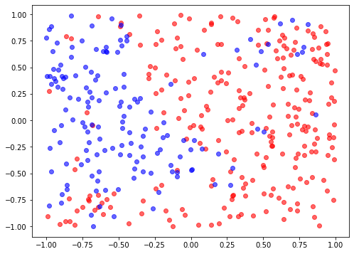

```python
# plot the data points

plt.figure(figsize=(8,6))
pos_idx = data_Q4['label'] == 1.0
plt.scatter(data_Q4['x1'].loc[pos_idx], data_Q4['x2'].loc[pos_idx],
            color='red', alpha=0.6)
neg_idx = data_Q4['label'] == -1.0
plt.scatter(data_Q4['x1'].loc[neg_idx], data_Q4['x2'].loc[neg_idx],
            color='blue', alpha=0.6);
```

```python
# split data

X_q4 = data_Q4[['x1','x2']]
y_q4 = data_Q4['label']
X_train, X_test, y_train, y_test = train_test_split(X_q4, y_q4,
                                                    test_size=0.20, random_state=2022)
```

```python
def plotClassifier(model, X, y):
    """plots the decision boundary of the model and the scatterpoints
       of the target values 'y'.

    Assumptions
    -----------
    y : it should contain two classes: '1' and '2'

    Parameters
    ----------
    model : the trained model which has the predict function

    X : the N by D feature array

    y : the N element vector corresponding to the target values

    """
    x1 = X[:, 0]
    x2 = X[:, 1]

    x1_min, x1_max = int(x1.min()) - 1, int(x1.max()) + 1
    x2_min, x2_max = int(x2.min()) - 1, int(x2.max()) + 1

    x1_line =  np.linspace(x1_min, x1_max, 200)
    x2_line =  np.linspace(x2_min, x2_max, 200)

    x1_mesh, x2_mesh = np.meshgrid(x1_line, x2_line)

    mesh_data = np.c_[x1_mesh.ravel(), x2_mesh.ravel()]

    y_pred = np.array(model.predict(mesh_data))
    y_pred = np.reshape(y_pred, x1_mesh.shape)

    plt.figure()
    plt.xlim([x1_mesh.min(), x1_mesh.max()])
    plt.ylim([x2_mesh.min(), x2_mesh.max()])

    plt.contourf(x1_mesh, x2_mesh, -y_pred.astype(int), # unsigned int causes problems with negative sign... o_O
                cmap=plt.cm.RdBu, alpha=0.6)


    y_vals = np.unique(y)
    plt.scatter(x1[y==y_vals[0]], x2[y==y_vals[0]], color="b", label="class %+d" % y_vals[0])
    plt.scatter(x1[y==y_vals[1]], x2[y==y_vals[1]], color="r", label="class %+d" % y_vals[1])
    plt.legend()
```

### SVC with different kernels

### 4.1. Train a soft-margin SVM with linear kernel and C = 100

```python
import matplotlib.gridspec as gridspec
from mlxtend.plotting import plot_decision_regions
```

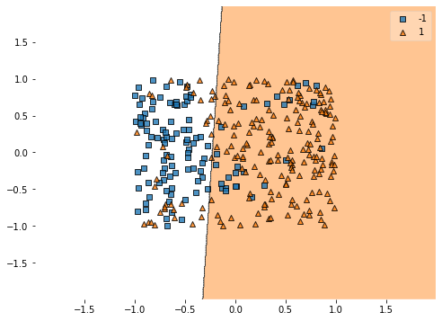

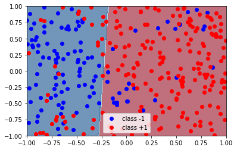

```python
C1=100
# fit the svc model
svc_clf_l = SVC(kernel='linear', C=C1)
svc_clf_l.fit(X_q4, y_q4)

fig = plt.subplots(figsize=(8,6))
plot_decision_regions(np.array(X_train), np.array(y_train.astype(int)), svc_clf_l);
plotClassifier(svc_clf_l, np.array(X_train), np.array(y_train));
```

```python
y_pred = svc_clf_l.predict(X_test)
y_train_pred = svc_clf_l.predict(X_train)
training_error_l = 1 - accuracy_score(y_train, y_train_pred)
test_error_l = 1 - accuracy_score(y_test, y_pred)
print('training error  when using linear kernel is:')
print(training_error_l)

print('testing error  when using linear kernel is:')
print(test_error_l)
```

```
training error  when using linear kernel is:
0.19687500000000002
testing error  when using linear kernel is:
0.23750000000000004
```

### 4.2. Train a soft-margin SVM with polynomial kernel

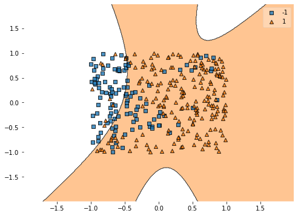

```python
# fit the svc model
svc_clf_poly = SVC(kernel='poly', C=C1)
svc_clf_poly.fit(X_q4, y_q4)

fig = plt.subplots(figsize=(8,6))
plot_decision_regions(np.array(X_train), np.array(y_train.astype(int)), svc_clf_poly);
```

```python
y_pred = svc_clf_poly.predict(X_test)
y_train_pred_p = svc_clf_poly.predict(X_train)
training_error_poly = 1 - accuracy_score(y_train, y_train_pred_p)
test_error_poly = 1 - accuracy_score(y_test, y_pred)
print('training error  when using polynomial kernel is:')
print(training_error_poly)

print('testing error  when using polynomial kernel is:')
print(test_error_poly)
```

[output not shown]

### 4.3. Train a soft-margin SVM with RBF kernel

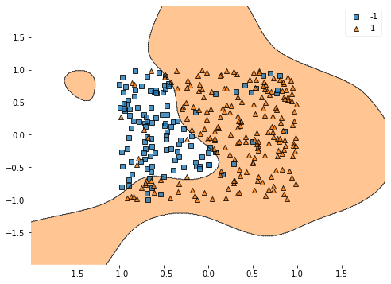

```python
# fit the svc model
svc_clf_rbf = SVC(kernel='rbf', C=C1)
svc_clf_rbf.fit(X_q4, y_q4)

fig = plt.subplots(figsize=(8,6))
plot_decision_regions(np.array(X_train), np.array(y_train.astype(int)), svc_clf_rbf);
```

```python
y_pred = svc_clf_rbf.predict(X_test)
y_train_pred_rbf = svc_clf_rbf.predict(X_train)
training_error_rbf = 1 - accuracy_score(y_train, y_train_pred_rbf)
test_error_rbf = 1 - accuracy_score(y_test, y_pred)
print('training error  when using rbf kernel is:')
print(training_error_rbf)

print('testing error  when using rbf kernel is:')
print(test_error_rbf)
```

```
training error  when using rbf kernel is:
0.10312500000000002
testing error  when using rbf kernel is:
0.15000000000000002
```

### 4.4. RBF with different gammas

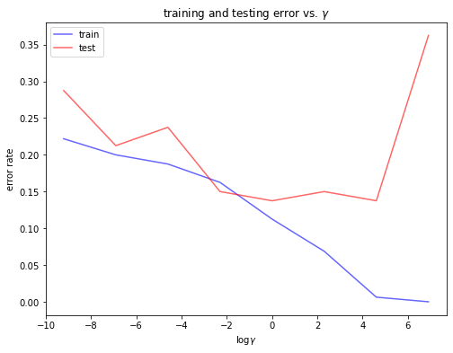

```python
gammas = [0.0001, 0.001, 0.01, 0.1, 1, 10, 100, 1000]

log_gamma = [np.log(g) for g in gammas]

# def PlotRBFError():
train_error_rbf = []
test_error_rbf = []
# train SVC with different gammas
for gamma in gammas:

    svc_rbf = SVC(kernel='rbf', C=C1, gamma = gamma)
    svc_rbf.fit(X_train, y_train)
    # report training error
    y_train_pred = svc_rbf.predict(X_train)
    train_error = 1 - accuracy_score(y_train, y_train_pred)
    train_error_rbf.append(train_error)

    # report testing error
    y_pred = svc_rbf.predict(X_test)
    test_error = 1 - accuracy_score(y_test, y_pred)
    test_error_rbf.append(test_error)



# plot train and test error w.r.t. gamma
fig = plt.subplots(figsize=(8,6))
plt.plot(log_gamma, train_error_rbf, color='blue', alpha=0.6)
plt.plot(log_gamma, test_error_rbf, color='red', alpha=0.6)
plt.title(u'training and testing error vs. $\gamma$');
plt.legend(['train','test'])
plt.xlabel(u'log$\gamma$')
plt.ylabel('error rate');
```

What do you notice about the error rates as $\gamma$ increases? Why this is the case? Finally, in the bias variance tradeoff, does small $\gamma$ correspond to high bias or high variance?  
Answer:

As $\gamma$ increases, the decision boundary will be closer to data points, and thus could classify more accurately. However, if $\gamma$ gets too high, it may overfit.

Small $\gamma$ correspond to high bias. Because it tends to underfit.

### Logistic Regression with Different Kernels

```python
import pickle
import os
from sklearn.model_selection import train_test_split
import numpy as np
import pandas as pd
import matplotlib.pyplot as plt
from scipy.optimize import approx_fprime
from numpy.linalg import norm
import math
```

```python
def check_gradient(model, X, y, dimensionality, verbose=True):
    # This checks that the gradient implementation is correct
    w = np.random.rand(dimensionality)
    f, g = model.funObj(w, X, y)

    # Check the gradient
    estimated_gradient = approx_fprime(w,
                                       lambda w: model.funObj(w,X,y)[0],
                                       epsilon=1e-6)

    implemented_gradient = model.funObj(w, X, y)[1]

    if np.max(np.abs(estimated_gradient - implemented_gradient) > 1e-3):
        raise Exception('User and numerical derivatives differ:\n%s\n%s' %
             (estimated_gradient[:5], implemented_gradient[:5]))
    else:
        if verbose:
            print('User and numerical derivatives agree.')
```

```python
def log_1_plus_exp_safe(x):
    out = np.log(1+np.exp(x))
    out[x > 100] = x[x>100]
    out[x < -100] = np.exp(x[x < -100])
    return out
```

```python
def findMin(funObj, w, maxEvals, *args, verbose=0):
    """
    Uses gradient descent to optimize the objective function

    This uses quadratic interpolation in its line search to
    determine the step size alpha
    """
    # Parameters of the Optimization
    optTol = 1e-2
    gamma = 1e-4

    # Evaluate the initial function value and gradient
    f, g = funObj(w,*args)
    funEvals = 1

    alpha = 1.
    while True:
        # Line-search using quadratic interpolation to
        # find an acceptable value of alpha
        gg = g.T.dot(g)

        while True:
            w_new = w - alpha * g
            f_new, g_new = funObj(w_new, *args)

            funEvals += 1
            if f_new <= f - gamma * alpha*gg:
                break

            if verbose > 1:
                print("f_new: %.3f - f: %.3f - Backtracking..." % (f_new, f))

            # Update step size alpha
            alpha = (alpha**2) * gg/(2.*(f_new - f + alpha*gg))

        # Print progress
        if verbose > 0:
            print("%d - loss: %.3f" % (funEvals, f_new))

        # Update step-size for next iteration
        y = g_new - g
        alpha = -alpha*np.dot(y.T,g) / np.dot(y.T,y)

        # Safety guards
        if np.isnan(alpha) or alpha < 1e-10 or alpha > 1e10:
            alpha = 1.

        if verbose > 1:
            print("alpha: %.3f" % (alpha))

        # Update parameters/function/gradient
        w = w_new
        f = f_new
        g = g_new

        # Test termination conditions
        optCond = norm(g, float('inf'))

        if optCond < optTol:
            if verbose:
                print("Problem solved up to optimality tolerance %.3f" % optTol)
            break

        if funEvals >= maxEvals:
            if verbose:
                print("Reached maximum number of function evaluations %d" % maxEvals)
            break

    return w, f
```

```python
class kernelLogRegL2():
    def __init__(self, lammy=1.0, verbose=0, maxEvals=100,
                 kernel_fun=kernel_linear, **kernel_args):
        self.verbose = verbose
        self.lammy = lammy
        self.maxEvals = maxEvals
        self.kernel_fun = kernel_fun
        self.kernel_args = kernel_args

    def funObj(self, u, K, y):
        yKu = y * (K@u)

        # Calculate the function value
        # f = np.sum(np.log(1. + np.exp(-yKu)))
        f = np.sum(log_1_plus_exp_safe(-yKu))

        # Add L2 regularization
        f += 0.5 * self.lammy * u.T@K@u

        # Calculate the gradient value
        res = - y / (1. + np.exp(yKu))
        g = (K.T@res) + self.lammy * K@u

        return f, g


    def fit(self, X, y):
        n, d = X.shape
        self.X = X

        K = self.kernel_fun(X,X, **self.kernel_args)

        check_gradient(self, K, y, n, verbose=self.verbose)
        self.u, f = findMin(self.funObj, np.zeros(n), self.maxEvals,
                            K, y, verbose=self.verbose)

    def predict(self, Xtest):
        Ktest = self.kernel_fun(Xtest, self.X, **self.kernel_args)
        return np.sign(Ktest@self.u)
```

```python
def kernel_linear(X1, X2):
    return X1 @ X2.T

def kernel_poly(X1, X2, p=2):
    #Your code here
    return (1 + X1 @ X2.T)**2


def kernel_RBF(X1, X2, sigma=0.5):

    mat = np.array([[1]* len(X2) for x in range(len(X1))])

    for i in range(len(X1)):
        for j in range(len(X2)):
            mat[i][j] = math.dist(X1[i,:], X2[j,:])

    result = np.exp(-1 * mat / sigma**2)

    return result
```

### 4.5. Train a L2 regularized Logistic Regression classifier with linear kernel, $\lambda$ = 0.01, and report training and testing error.

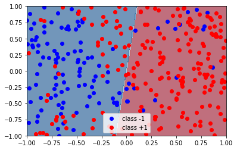

```python
kernelLog_linear = kernelLogRegL2(lammy=0.01)
kernelLog_linear.fit(X_train, y_train)
plotClassifier(kernelLog_linear, np.array(X_train), np.array(y_train))
```

```python
y_train_linear = kernelLog_linear.predict(X_train)
y_pred_linear = kernelLog_linear.predict(X_test)
log_l_train_error = 1 - accuracy_score(y_train, y_train_linear)
log_l_test_error = 1 - accuracy_score(y_test, y_pred_linear)
print('logistic regression training error when using linear kernel is:')
print(log_l_train_error)

print('logistic regression testing error when using linear kernel is:')
print(log_l_test_error)
```

```
logistic regression training error when using linear kernel is:
0.23750000000000004
logistic regression testing error when using linear kernel is:
0.23750000000000004
```

### 4.6. Train a L2 regularized Logistic Regression classifier with polynomial kernel, $\lambda$ = 0.01, and report training and testing error.

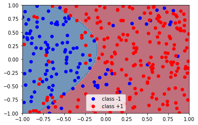

```python
kernelLog_poly = kernelLogRegL2(lammy=0.01, kernel_fun = kernel_poly)
kernelLog_poly.fit(X_train, y_train)
plotClassifier(kernelLog_poly, np.array(X_train), np.array(y_train))
```

```python
y_train_poly = kernelLog_poly.predict(X_train)
y_pred_poly = kernelLog_poly.predict(X_test)
log_p_train_error = 1 - accuracy_score(y_train, y_train_poly)
log_p_test_error = 1 - accuracy_score(y_test, y_pred_poly)
print('logistic regression training error when using polynomial kernel is:')
print(log_p_train_error)

print('logistic regression testing error when using polynomial kernel is:')
print(log_p_test_error)
```

```
logistic regression training error when using polynomial kernel is:
0.18437499999999996
logistic regression testing error when using polynomial kernel is:
0.23750000000000004
```

### 4.7. Train a L2 regularized Logistic Regression classifier with RBF kernel, $\lambda$ = 0.01, $\sigma=0.5$, and report training and testing error.

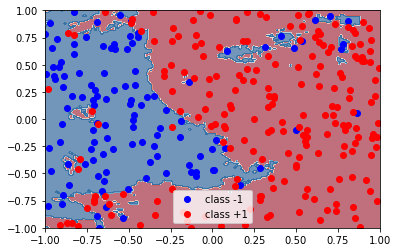

```python
kernelLog_rbf = kernelLogRegL2(lammy=0.01, kernel_fun = kernel_RBF)
kernelLog_rbf.fit(X_train.values, y_train.values)
plotClassifier(kernelLog_rbf, np.array(X_train), np.array(y_train))
```

```python
y_train_rbf = kernelLog_rbf.predict(X_train.values)
y_pred_rbf = kernelLog_rbf.predict(X_test.values)
log_rbf_train_error = 1 - accuracy_score(y_train, y_train_rbf)
log_rbf_test_error = 1 - accuracy_score(y_test, y_pred_rbf)
print('logistic regression training error when using RBF kernel is:')
print(log_rbf_train_error)

print('logistic regression testing error when using RBF kernel is:')
print(log_rbf_test_error)
```

```
logistic regression training error when using RBF kernel is:
0.043749999999999956
logistic regression testing error when using RBF kernel is:
0.16249999999999998
```

```python
train_error48 = []
test_error48 = []
gammas = [0.0001, 0.001, 0.01, 0.1, 1, 10, 100]
for gamma in gammas:

    sigma = np.sqrt(1 / gamma)
    kernelLog_rbf48 = kernelLogRegL2(lammy=0.01, kernel_fun = kernel_RBF, sigma=sigma)
    kernelLog_rbf48.fit(X_train.values, y_train.values)
    y_train_rbf48 = kernelLog_rbf48.predict(X_train.values)
    y_pred_rbf48 = kernelLog_rbf48.predict(X_test.values)
    log_rbf_train_error48 = 1 - accuracy_score(y_train, y_train_rbf48)
    log_rbf_test_error48 = 1 - accuracy_score(y_test, y_pred_rbf48)
    train_error48.append(log_rbf_train_error48)
    test_error48.append(log_rbf_test_error48)
```

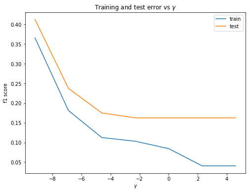

```python
log_gamma = [np.log(g) for g in gammas]
fig48, ax48 = plt.subplots(figsize=(8,6))
plt.plot(log_gamma, train_error48)
plt.plot(log_gamma, test_error48);
plt.xlabel(u'$\gamma$')
plt.ylabel('f1 score')
plt.legend(['train', 'test'])
plt.title(u'Training and test error vs $\gamma$');
```

## Q5 Sparse Logistic Regression

### 5.1 plot ROC curve

```python
from sklearn.linear_model import LogisticRegression
from sklearn import metrics, model_selection
```

```python
df_q5 = pd.read_csv('spectf.csv',header=None)
df_q5.shape
# df_q5.head()
```

```
(267, 45)
```

```python
X_q5 = df_q5.iloc[:,1:]
y_q5 = df_q5.iloc[:, 0]
X_train_q5, X_test_q5, y_train_q5, y_test_q5 = train_test_split(X_q5, y_q5,
                                                    test_size=0.25, random_state=2022)
```

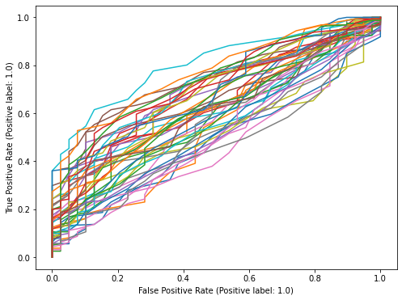

```python
features = X_train_q5.columns
fig5, ax5 = plt.subplots(figsize=(8,6))
# y_train5 = np.array(y_train_q5).reshape(-1,1)
# y_test5 = np.array(y_test_q5).reshape(-1,1)
# fig5, ax5 = plt.subplots(figsize=(8,6))
aucs = {}
for f in features:
    X = np.array(X_train_q5[f]).reshape(-1,1)
    log_clf = LogisticRegression(penalty='none',random_state=0).fit(X=X, y=y_train_q5)
#     X_test5 = np.array(X_test_q5[f]).reshape(-1,1)
    y_pred5 = log_clf.predict(X)

    metrics.plot_roc_curve(log_clf, X, y_train_q5, ax=ax5)
    auc = metrics.roc_auc_score(y_train_q5, y_pred5)
    aucs[f] = auc
    ax5.get_legend().remove()
# plt.show()
```

### 5.2 Create an algorithm for choosing 300 different subsets of these features

```python
# Covariance matrix
X_array = np.array(X_train_q5)
cov = np.cov(X_array.T)
mean_var = np.mean(cov)

# extract features that have AUC score above 0.5
auc_above = {}     # featurs with AUC above 0.5
auc_low = {}      # all other features
for key, value in aucs.items():
    if value > 0.5:
        auc_above[key] = value

    else:
        auc_low[key] = value


# number of features
n_subsets = 0
subsets = []
# for each such feature, iterate all other features
while n_subsets < 300:
    # for each feature with a higher AUC, keep it
    # and search for other features
    for k, v in auc_above.items():
        for k1, v1 in aucs.items():
            if k != k1:
                cov_k = cov[k-1,k1-1]    # check the covriance
                if cov_k < mean_var:
                    # only take two features that are not highly correlated
                    subsets.append([k,k1])
                    n_subsets += 1
#     print(n_subsets)
# while n_subsets < 300:
    for k2, v2 in auc_low.items():
        for k3, v3 in aucs.items():
            if (k2 != k3) and ([k2,k3] or [k3,k2] not in subsets):
                # exclude identical subsets
                cov_k_ = cov[k2-1,k3-1]
                if cov_k < mean_var:
                    subsets.append([k2,k3])
                    n_subsets += 1


subsets1 = subsets[:300]
```

### 5.3 Train 300 logistic regression models by calling a logistic regression solver on each subset of data

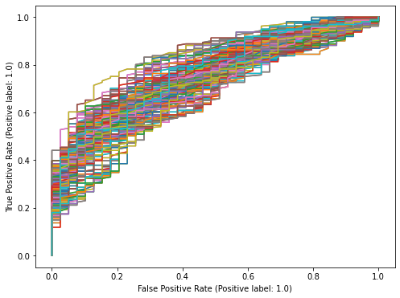

```python
auc53 = {}
fig53, ax53 = plt.subplots(figsize=(8,6))
for idx, s in enumerate(subsets1):
    X_3 = X_train_q5[[s[0],s[1]]]
    log_clf53 = LogisticRegression(penalty='none',random_state=0).fit(X=X_3, y=y_train_q5)
#     X_test5 = np.array(X_test_q5[f]).reshape(-1,1)
    y_pred53 = log_clf53.predict(X_3)
    # plot ROC
    metrics.plot_roc_curve(log_clf53, X_3, y_train_q5, ax=ax53)
    auc1 = metrics.roc_auc_score(y_train_q5, y_pred53)
    auc53[idx] = auc1
ax53.get_legend().remove()
```

```python
max_auc = max(auc53.values())
# min(auc53.values())

def ReturnKey(dictionary, value):

    for k,v in dictionary.items():
        if v == value:

            key = k
    return k

idxmax = ReturnKey(auc53, max_auc)
```

```python
# subset with the highest the AUC among all 300 subsets I chose
subset_max = subsets[idxmax]
subset_max
```

```
[43, 36]
```

### 5.4 Put the training ROC for f and the test ROC for f on the same figure and report the test AUC.

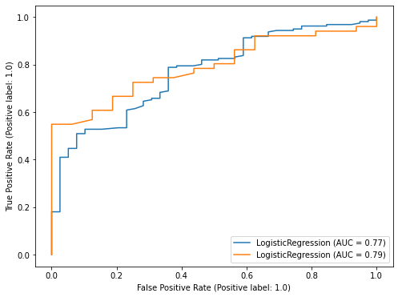

```python
X_train_best = X_train_q5[[subset_max[0],subset_max[1]]]
X_test_best = X_test_q5[[subset_max[0],subset_max[1]]]
log_clf_best = LogisticRegression(penalty='none',random_state=0).fit(
                                        X=X_train_best, y=y_train_q5)

y_train_pred = log_clf_best.predict(X_train_best)
y_test_pred = log_clf_best.predict(X_test_best)

fig54, ax54 = plt.subplots(figsize=(8,6))
metrics.plot_roc_curve(log_clf_best, X_train_best, y_train_q5, ax=ax54)
metrics.plot_roc_curve(log_clf_best, X_test_best, y_test_q5, ax=ax54);
```

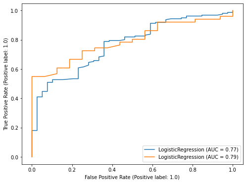

```python
# l2 regularized logistic regression

log_clf_l2 = LogisticRegression(penalty='l2',random_state=0).fit(
                                        X=X_train_best, y=y_train_q5)

y_train_pred = log_clf_l2.predict(X_train_best)
y_test_pred = log_clf_l2.predict(X_test_best)

fig541, ax541 = plt.subplots(figsize=(8,6))
metrics.plot_roc_curve(log_clf_l2, X_train_best, y_train_q5, ax=ax541)
metrics.plot_roc_curve(log_clf_l2, X_test_best, y_test_q5, ax=ax541);
```

It seems this technique works roughly the same as l2-regularized logistic regression.